Personalised feedback prototype

# Hello Evan D!

This is an example showing how different text/visual elements can be generated in an email.

## Use precalculated values/strings using inline R code

You made 21 records of 8 species!

These were Red Admiral, Holly Blue, Meadow brown, Painted Lady, Comma, Peacock, Common Blue, Large white.

## Use precalculated values for generating insight

Other recorders made on average 25 records of an average of 7.75 species!

## Print tables using knitr::kable()

Your most recent records

| Species | Date |
| --- | --- |
| Meadow brown | 2024-06-30 |
| Meadow brown | 2024-06-27 |
| Comma | 2024-06-26 |
| Red Admiral | 2024-06-24 |
| Meadow brown | 2024-06-23 |
| Red Admiral | 2024-06-22 |

## Add plots through {ggplot2}

Here’s a plot of your recent recording activity from 2024-06-03 to 2024-06-30.

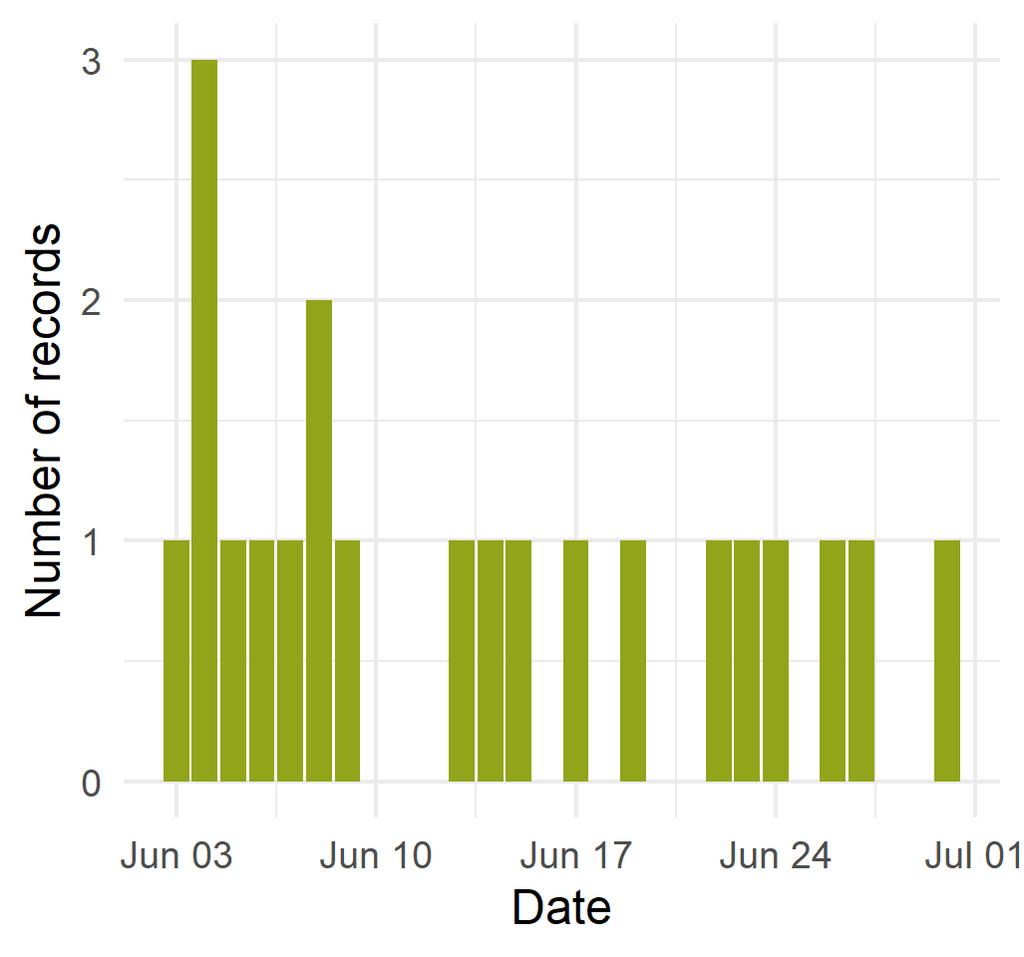

## Add static maps with {ggspatial}

Here are your 21 records plotted on a map.

[figure not shown]

## Include images

And here is an image inserted using R code.

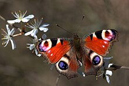

## Buttons and links

Links can be done using markdown syntax such as [this is a link](https://www.irecord.org.uk)

Buttons in emails are not as straightforward as you might think, here’s a way to do it in R.

[Click here](https://www.irecord.org.uk)

If you wish to stop receiving these emails, you may unsubscribe here.